A couple of years ago, I wrote about rain on different days of the week in Philadelphia. I was annoyed because it felt like, every time I took out the trash, it was raining. This is something I only noticed because I live in a row home and I have to lug my trash cans from my back yard through my house to the front.

Our trash day is Wednesdays, so I take it out on Tuesday nights. When I did that analysis, I found that, sure enough, it did rain more on Tuesdays! Maybe not that interesting - it’s gotta rain more on some day, right? The surprising thing though was that the confidence interval for Tuesday did not include 0. So I could reject my null hypothesis that it rained the same amount on each day.

At the time, my view was that this was a fluke of randomness; occassionally you will find a result that looks like there is something going on when there isn’t. Obviously the day of the week doesn’t impact the weather. I was really just joking when I did it the first time and didn’t expect to find anything.

However, maybe a Bayesian approach will give us an answer that we know is more in line with reality.

```r
library(tidyverse)
library(lubridate)
library(here)
library(rstanarm)
library(jtcr)
library(broom)
library(pROC)

theme_set(theme_jtc())

# use same data that goes up to September 2018
weather <- "https://jtcies.com/data/phl_weather_20090925-20180924.csv" %>%
  read_csv(guess_max = 2000) %>%
  janitor::clean_names()
weather_processed <- weather %>%
    mutate(
        dow = as.factor(wday(date)),
        rain = as.integer(prcp > 0)
    )
```

Below is the percentage of days that it rained in Philadelphia by day of the week:

```r
weather_processed %>%
    group_by(dow) %>%
    summarise(
        n = n(),
        avg_days_of_rain = mean(rain)
    ) %>%
    knitr::kable()
```

| dow | n | avg_days_of_rain |
| --- | --- | --- |
| 1 | 469 | 0.2857143 |
| 2 | 469 | 0.3198294 |
| 3 | 469 | 0.3859275 |
| 4 | 469 | 0.3262260 |
| 5 | 469 | 0.3411514 |
| 6 | 470 | 0.3063830 |
| 7 | 469 | 0.3176972 |

We’ll fit four models to see how the priors impact the coefficients. My assumption is that the day of the week has no impact on whether it rains so models that produce coefficients closer to zero should be closer to what we’d expect. The first model is a liklihood model and the next three are Bayesian models with increasingly informative priors.

```r
mod1 <- glm(
    rain ~ dow,
    family = binomial(link = "logit"),
    data = weather_processed
)

mod2 <- stan_glm(
    rain ~ 1 + dow,
    family = binomial(link = "logit"),
    data = weather_processed,
    prior = normal(0, 0.5),
    prior_intercept = normal(-0.8, 1)
)
mod3 <- stan_glm(
    rain ~ 1 + dow,
    family = binomial(link = "logit"),
    data = weather_processed,
    prior = normal(0, 0.25),
    prior_intercept = normal(-0.8, 1)
)
mod4 <- stan_glm(
    rain ~ 1 + dow,
    family = binomial(link = "logit"),
    data = weather_processed,
    prior = normal(0, 0.1),
    prior_intercept = normal(-0.8, 1)
)
```

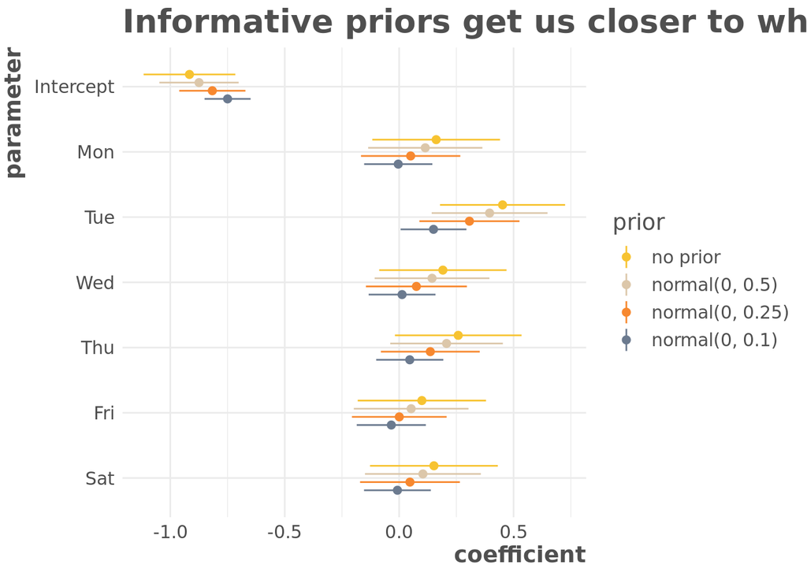

```r
extract_coef <- function(x) {

    labels <-  c("Intercept", as.character(wday(2:7, label = TRUE)))
    priors <- prior_summary(x)$prior
    dist <- priors$dist
    mu <- unique(priors$location)
    sigma <- unique(priors$scale)

    if (is.null(priors)) {
            prior_label <- "no prior"
    } else {
        prior_label <- paste0(dist, "(", mu, ", ", sigma, ")")
    }

    tidy(x) %>%
        mutate(param = labels,
               prior = prior_label)
}

results <- list(mod1, mod2, mod3, mod4) %>%
    map_dfr(extract_coef, .id = "model")

results %>%
    mutate(param = fct_rev(fct_inorder(param)),
           prior = fct_rev(fct_inorder(prior))) %>%
    ggplot(aes(param, estimate, color = prior)) +
        geom_point(
            size = 2,
            position = position_dodge(width = 0.5)
        ) +
        geom_linerange(
            aes(ymin = estimate - 1.96 * std.error,
                ymax = estimate + 1.96 * std.error),
            position = position_dodge(width = 0.5)
        ) +
        coord_flip() +
        color_jtc("color") +
        guides(color = guide_legend(reverse = TRUE)) +
        labs(
            title = "Informative priors get us closer to what we expect",
            y = "coefficient",
            x = "parameter"
        )
```

The informative priors don’t substantially change the predictions in this example. There are very slight differences with more informative priors having a negative impact on in-sample fit and a better impact on out-of-sample fit.

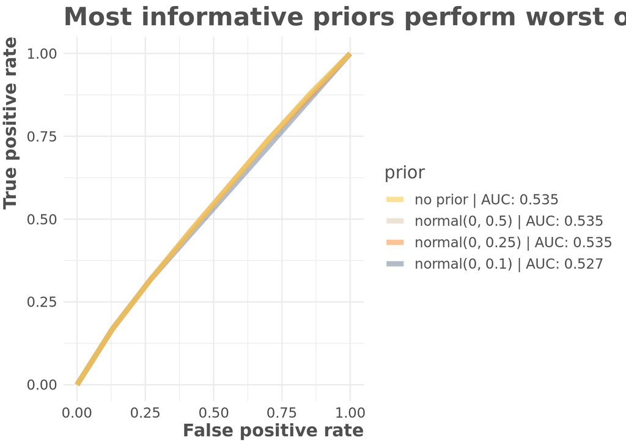

```r
calc_roc <- function(x) {
    preds <- augment(x, type.predict = "response")

    area_under <- auc(roc(preds, rain, .fitted,
                          direction = "<",
                          levels = c(0, 1)))

    threshold <- seq(0, 1, by = 0.01)

    pred_levels <- preds %>%
        nest(data = everything()) %>%
        crossing(threshold) %>%
        unnest(data) %>%
        mutate(
            tp = .fitted >= threshold & rain == 1,
            fp = .fitted > threshold & rain == 0
        )

    pred_levels %>%
        group_by(threshold) %>%
        summarise(
            tpr = sum(tp) / sum(rain == 1),
            fpr = sum(fp) / sum(rain == 0)
        ) %>%
        mutate(area_under = as.numeric(area_under))
}

list(mod1, mod2, mod3, mod4) %>%
    map_dfr(calc_roc, .id = "model") %>%
    left_join(
        results %>%
            distinct(model, prior),
        by = "model"
    ) %>%
    mutate(
        prior = paste0(prior, " | AUC: ", round(area_under, 3)),
        prior = fct_rev(fct_inorder(prior))
    ) %>%
    ggplot(aes(fpr, tpr, color = prior)) +
        geom_line(size = 2, alpha = 0.5) +
        expand_limits(y = c(0, 1), x = c(0, 1)) +
        color_jtc("color") +
        guides(color = guide_legend(reverse = TRUE)) +
        labs(title = "Most informative priors perform worst on in-sample predictions",
             x = "False positive rate",
             y = "True positive rate")
```

#### Informative priors perform best on out of sample predictions.

```r
loo_compare(loo(mod2), loo(mod3), loo(mod4)) %>%
    knitr::kable()
```

|  | elpd_diff | se_diff | elpd_loo | se_elpd_loo | p_loo | se_p_loo | looic | se_looic |
| --- | --- | --- | --- | --- | --- | --- | --- | --- |
| mod4 | 0.0000000 | 0.000000 | -2073.535 | 19.55427 | 3.736433 | 0.0512945 | 4147.070 | 39.10853 |
| mod3 | -0.1863042 | 1.243243 | -2073.721 | 19.69819 | 5.827222 | 0.0774617 | 4147.443 | 39.39638 |
| mod2 | -0.3995841 | 1.862989 | -2073.935 | 19.73888 | 6.574328 | 0.0863302 | 4147.869 | 39.47776 |

## Conclusion

So what’s the point of looking at this? My perspective is that you need to use the technique that fits the question you are trying to answer and the data you have. Informative priors are really only data falsification if you don’t have good reasons to use informative priors. We had a good reason to use informative priors here - the day of the week doesn’t do shit to the weather! It’s ridiculous to think that it does.

This does help to show how throwing a bunch of stuff at your model without some form of regularization or priors will occassionally find patterns that don’t exist in reality.